# Transcriptomic Validation of *CDC25C* and *AURKA* as Tumour-Associated Antigens in Hepatocellular Carcinoma

RNA-Seq Analysis of TCGA-LIHC Data in Support of an In Silico Multi-Epitope mRNA Vaccine

Daniel Amewoalor

June 16, 2026

# 1 Scientific Background and Rationale

## 1.1 Project Overview

Hepatocellular carcinoma (HCC) is the predominant form of primary liver cancer, accounting for approximately 75 to 85 percent of cases worldwide, and constitutes the third leading cause of cancer-related mortality globally (Llovet et al., 2021). Despite advances in surgical resection, ablation, and systemic therapies such as sorafenib and atezolizumab, long-term survival in advanced-stage disease remains poor, underscoring an urgent need for novel therapeutic modalities.

This document presents the **transcriptomic validation component** of a broader computational study aimed at designing a multi-epitope mRNA vaccine against HCC. The analysis leverages RNA-sequencing data from the TCGA-LIHC (Liver Hepatocellular Carcinoma) cohort, accessed through the NCI Genomic Data Commons (GDC), to establish that the two candidate vaccine antigens, *CDC25C* and *AURKA*, are significantly and consistently overexpressed in primary HCC tumours relative to adjacent normal liver tissue.

Establishing robust differential overexpression is a prerequisite for designating a protein as a **tumour-associated antigen (TAA)**: an antigen that can be safely targeted by the immune system because its expression is elevated or aberrant in malignant cells compared with healthy tissue. Confirming this property using bioinformatic methods constitute the first step in the immunoinformatics pipeline and directly justifies the subsequent epitope prediction, vaccine construct assembly, molecular docking, and immune simulation analyses described in the full study.

## 1.2 Biological Rationale for Target Selection

*CDC25C* (Cell Division Cycle 25C) is a dual-specificity phosphatase that activates the *CDK1*/*Cyclin B* complex, triggering the G2-to-M phase transition in the cell cycle. Its overexpression in HCC has been linked to uncontrolled mitotic entry, genomic instability, resistance to chemotherapeutic agents, and poor patient prognosis (Chan et al., 2012). Because *CDC25C* activity is largely dispensable in quiescent normal hepatocytes but becomes critical in rapidly cycling tumour cells, it represents a therapeutically relevant target with a favourable tumour-specific expression profile (Miao et. al, 2026).

*AURKA* (Aurora Kinase A) is a serine/threonine kinase that coordinates centrosome maturation, bipolar spindle assembly, and mitotic entry. *AURKA* amplification and overexpression in HCC promotes chromosomal instability, activates oncogenic signalling pathways including PI3K/AKT and Wnt/β-catenin, and is associated with metastatic progression and reduced overall survival (Du et al., 2021). Its kinase activity is selectively elevated in tumour tissue, making it a well-validated oncotarget and a source of immunogenic peptides. Importantly, both *CDC25C* and *AURKA* have been independently identified as candidate HCC antigens for mRNA vaccine development in transcriptomic screening studies (Lu et al., 2023; Wang et al., 2024), directly corroborating the target selection rationale of this study.

## 1.3 mRNA Vaccine Development and Immunoinformatics

mRNA vaccines have emerged as a powerful anti-cancer modality, demonstrated most prominently by the personalised neoantigen vaccine mRNA-4157 (Moderna/Merck) in combination with pembrolizumab for high-risk and resected melanoma (Carlino et al., 2026). Unlike DNA vaccines, mRNA constructs are non-integrating, rapidly manufacturable, and capable of eliciting robust cytotoxic T lymphocyte (CTL) responses through endogenous antigen processing and MHC class I presentation. The immunoinformatics approach applied here follows the epitope-based vaccine design framework described by Parvizpour et al. (2020), which provides a comprehensive bioinformatics workflow for antigen identification, epitope prediction, and multi-epitope construct assembly.

The computational pipeline applied in this study follows an established immunoinformatics workflow:

1. Transcriptomic validation of TAA overexpression (this document)
2. Prediction and filtering of CTL (CD8+), HTL (CD4+), and B cell epitopes using IEDB tools(NetMHCpan, NetMHCIIpan 4.1, Bepipred 2.0)
3. Multi-epitope vaccine construct assembly with adjuvants and linkers
4. Physicochemical characterisation, 3D structure modelling, and validation
5. Molecular docking against TLR2 and normal mode analysis
6. Molecular dynamics simulation and in silico immune simulation

# 2 Key Findings at a Glance

> **Analysis completed:** 2026-05-17 | **Dataset:** TCGA-LIHC | **Cohort:** 371 primary tumours + 50 solid tissue normal samples (total N = 421)

Table KF-1. TCGA-LIHC cohort dimensions and global differential expression summary.

| Metric | Value |
| --- | --- |
| Total samples | 421 |
| Primary tumour | 371 |
| Solid tissue normal | 50 |
| Genes tested | 49,291 |
| Significant DEGs (\|LFC\| > 1, padj < 0.05) | 9,421 |
| Upregulated in tumour | 7,553 |
| Downregulated in tumour | 1,868 |

Table KF-2. DESeq2 Wald test results for CDC25C and AURKA (Tumour vs. Normal). Both genes satisfy the significance threshold (padj < 0.05) and the biological relevance threshold (|log₂FC| > 1) with large margins.

| ENSEMBL ID | Gene | Base Mean | Log₂FC | LFC SE | Wald Statistic | P-value | Adj. P-value (BH) |
| --- | --- | --- | --- | --- | --- | --- | --- |
| ENSG00000087586 | AURKA | 796.53 | 2.682 | 0.1592 | 16.848 | 1.09 × 10⁻⁶³ | 4.14 × 10⁻⁶¹ |
| ENSG00000158402 | CDC25C | 193.72 | 4.349 | 0.2133 | 20.384 | 2.34 × 10⁻⁹² | 1.93 × 10⁻⁸⁸ |

**Headline result:** *CDC25C* is upregulated by **log₂FC = 4.35** (~20-fold) and *AURKA* by **log₂FC = 2.68** (~6.4-fold) in primary HCC tumours relative to normal liver tissue. Both results are genome-wide significant after Benjamini-Hochberg correction across 49,291 tested genes (*CDC25C*: padj = 1.93 × 10⁻⁸⁸; *AURKA*: padj = 4.14 × 10⁻⁶¹). *CDC25C* is overexpressed in **370 / 371 tumour samples (99.7%)** and *AURKA* in **365 / 371 (98.4%)**, confirming population-level tumour-associated antigen status.

Table KF-3. Overexpression frequency of CDC25C and AURKA relative to the normal tissue expression median.

| Gene | Tumour Samples (N) | Overexpressed vs. Normal Median (N) | Overexpressed (%) | Median Tumour Expr. (log₂) | Median Normal Expr. (log₂) |
| --- | --- | --- | --- | --- | --- |
| CDC25C | 371 | 370 | 99.73 | 7.3533 | 3.0813 |
| AURKA | 371 | 365 | 98.38 | 9.3936 | 6.8053 |

Table KF-4. Stratified Spearman co-expression analysis between CDC25C and AURKA.

[output not shown]

Table KF-5. Top 10 genome-wide co-expressed genes with CDC25C. All neighbours are established cell-cycle and spindle-checkpoint regulators, corroborating CDC25C’s role in the HCC mitotic transcriptional programme.

| Rank | Gene | ρ with CDC25C | ρ with AURKA |
| --- | --- | --- | --- |
| 1 | PTTG1 | 0.9335 | 0.7550 |
| 2 | BIRC5 | 0.9211 | 0.7790 |
| 3 | CDCA5 | 0.9121 | 0.7624 |
| 4 | SPC25 | 0.9115 | 0.7696 |
| 5 | CDC20 | 0.9107 | 0.7433 |
| 6 | NDC80 | 0.9102 | 0.7625 |
| 7 | KIF2C | 0.9092 | 0.7619 |
| 8 | CCNB1 | 0.9079 | 0.7954 |
| 9 | CDCA3 | 0.9063 | 0.7427 |
| 10 | SGO1 | 0.9047 | 0.7658 |

Table KF-6. Top 10 genome-wide co-expressed genes with AURKA. CDK1 and CCNB1 (Cyclin B1) top the list, consistent with AURKA’s established role in activating the CDK1-Cyclin B complex at the G2/M transition.

| Rank | Gene | ρ with CDC25C | ρ with AURKA |
| --- | --- | --- | --- |
| 1 | CDK1 | 0.8944 | 0.7959 |
| 2 | CCNB1 | 0.9079 | 0.7954 |
| 3 | BIRC5 | 0.9211 | 0.7790 |
| 4 | SKA1 | 0.8970 | 0.7756 |
| 5 | KIF4A | 0.8995 | 0.7755 |
| 6 | CCNB2 | 0.9015 | 0.7734 |
| 7 | CDKN3 | 0.8797 | 0.7719 |
| 8 | EXO1 | 0.8890 | 0.7715 |
| 9 | SPC25 | 0.9115 | 0.7696 |
| 10 | SKA3 | 0.8977 | 0.7686 |

# 3 Environment Setup

All R packages required for this analysis are listed below. The helper function `load_packages()` automatically installs any missing CRAN or Bioconductor dependencies before loading them, ensuring full reproducibility on a fresh R installation.

```r
# Helper function: installs missing packages then loads all
load_packages <- function(pkgs) {

  cran_pkgs <- c("dplyr", "tidyr", "ggplot2", "ggpubr", "ggrepel",
                 "pheatmap", "RColorBrewer", "gridExtra", "scales",
                 "viridis", "cowplot")

  bioc_pkgs <- c("TCGAbiolinks", "SummarizedExperiment", "DESeq2",
                 "org.Hs.eg.db", "clusterProfiler", "enrichplot",
                 "AnnotationDbi", "BiocParallel", "apeglm")

  missing_cran <- setdiff(pkgs[pkgs %in% cran_pkgs], rownames(installed.packages()))
  if (length(missing_cran) > 0)
    install.packages(missing_cran, dependencies = TRUE)

  missing_bioc <- setdiff(pkgs[pkgs %in% bioc_pkgs], rownames(installed.packages()))
  if (length(missing_bioc) > 0) {
    if (!requireNamespace("BiocManager", quietly = TRUE))
      install.packages("BiocManager")
    BiocManager::install(missing_bioc, ask = FALSE, update = FALSE)
  }

  invisible(lapply(pkgs, library, character.only = TRUE))
}

required_packages <- c(
  "TCGAbiolinks", "SummarizedExperiment", "DESeq2",
  "dplyr", "tidyr", "ggplot2", "ggpubr", "ggrepel",
  "pheatmap", "RColorBrewer", "org.Hs.eg.db",
  "clusterProfiler", "enrichplot", "AnnotationDbi",
  "BiocParallel", "apeglm", "scales", "viridis", "cowplot"
)

load_packages(required_packages)

# Global reproducibility seed
set.seed(42)

# Parallelisation backend
register(SnowParam(workers = 2))

# Shared colour palette (tumour = red; normal = blue; consistent across all figures)
PALETTE <- c(
  Primary_Tumor       = "#E74C3C",
  Solid_Tissue_Normal = "#3498DB",
  Upregulated         = "#E74C3C",
  Downregulated       = "#3498DB",
  "Not Significant"   = "grey70"
)

# Candidate vaccine antigens
TARGET_GENES <- c("CDC25C", "AURKA")

# Label map: internal factor levels → display labels used in all figures
LABEL_MAP <- c(
  Primary_Tumor       = "Primary Tumour",
  Solid_Tissue_Normal = "Normal Tissue"
)

# Helper: save a ggplot with consistent settings
save_plot <- function(plot, filename, width, height, dpi = 600) {
  ggsave(
    filename = file.path("figures", paste0(filename, ".png")),
    plot     = plot,
    width    = width,
    height   = height,
    dpi      = dpi
  )
  invisible(plot)
}

# Helper: save a pheatmap object
save_pheatmap <- function(x, filename, width, height, dpi = 600) {
  png(file.path("figures", paste0(filename, ".png")),
      width = width, height = height, units = "in", res = dpi)
  grid::grid.newpage()
  grid::grid.draw(x$gtable)
  dev.off()
  invisible(x)
}

# Output directories
dir.create("figures", showWarnings = FALSE)
dir.create("results",  showWarnings = FALSE)

message("Environment ready. Proceeding with analysis.")
```

# 4 TCGA-LIHC Data Retrieval

Raw gene expression count data are retrieved directly from the NCI GDC using the `TCGAbiolinks` package. Only STAR-generated unstranded raw counts are requested, as these are required as integer input for the negative binomial modelling framework implemented in DESeq2. A local caching mechanism prevents redundant downloads on subsequent runs.

```r
# Construct the GDC query for TCGA-LIHC RNA-Seq data
query <- GDCquery(
  project       = "TCGA-LIHC",
  data.category = "Transcriptome Profiling",
  data.type     = "Gene Expression Quantification",
  workflow.type = "STAR - Counts",        # Unstranded raw counts required by DESeq2
  sample.type   = c("Primary Tumor", "Solid Tissue Normal")
)

# Download data only when no local cache exists
if (!dir.exists("GDCdata")) {
  message("Downloading TCGA-LIHC data from the GDC portal. This may take several minutes.")
  GDCdownload(query, method = "api", files.per.chunk = 5)
} else {
  message("Local GDCdata/ folder detected. Skipping download and using cached data.")
}

# Assemble a SummarizedExperiment object from the downloaded files
se <- GDCprepare(query)

message(sprintf("Dataset loaded: %d genes x %d samples", nrow(se), ncol(se)))
```

# 5 Quality Control and Pre-processing

## 5.1 Sample Annotation Harmonisation

TCGAbiolinks stores sample classification information in different column names depending on the package version and data release. The code below resolves this ambiguity by detecting the appropriate column and coercing labels to a consistent two-level factor used throughout the remainder of the analysis.

```r
col_data <- as.data.frame(colData(se))

# Detect and harmonise sample type label
if ("definition" %in% colnames(col_data)) {
  col_data$sample_type <- dplyr::recode(
    col_data$definition,
    "Primary solid Tumor" = "Primary Tumor",
    "Solid Tissue Normal" = "Solid Tissue Normal",
    .default              = NA_character_
  )
} else if ("sample_type" %in% colnames(col_data)) {
  col_data$sample_type <- as.character(col_data$sample_type)
} else {
  stop("Cannot identify sample_type column. Inspect names(colData(se)) and adjust accordingly.")
}

# Standardise labels and set factor levels (Normal = reference)
col_data$sample_type <- factor(
  dplyr::recode(col_data$sample_type,
                "Primary Tumor"       = "Primary_Tumor",
                "Solid Tissue Normal" = "Solid_Tissue_Normal"),
  levels = c("Primary_Tumor", "Solid_Tissue_Normal")
)

# Remove samples with unresolvable sample type annotation
keep_samples <- !is.na(col_data$sample_type)
se           <- se[, keep_samples]
col_data     <- col_data[keep_samples, ]
colData(se)  <- DataFrame(col_data)

message(sprintf("Post-QC cohort: %d primary tumour samples | %d solid tissue normal samples",
                sum(col_data$sample_type == "Primary_Tumor"),
                sum(col_data$sample_type == "Solid_Tissue_Normal")))
```

## 5.2 Raw Count Matrix Extraction

```r
# Extract unstranded raw counts (required format for DESeq2)
count_matrix <- assay(se, "unstranded")

# Integrity checks: counts must be non-negative integers
stopifnot(all(count_matrix >= 0))
stopifnot(all(count_matrix == round(count_matrix)))

message(sprintf("Count matrix dimensions: %d genes x %d samples", nrow(count_matrix), ncol(count_matrix)))
```

# 6 Differential Expression Analysis (DESeq2)

## 6.1 Model Construction and Filtering

The DESeq2 negative binomial model is constructed using sample type (Primary Tumour vs. Solid Tissue Normal) as the sole design variable. Solid Tissue Normal is set as the reference level, so all log2 fold-change estimates are interpreted as the tumour-relative change. Low-abundance genes (fewer than 10 total counts across all samples) are removed prior to model fitting to increase statistical power and reduce the multiple testing burden.

```r
# Build DESeqDataSet
dds <- DESeqDataSetFromMatrix(
  countData = count_matrix,
  colData   = col_data,
  design    = ~ sample_type
)

# Set reference level: fold-change direction = Tumour / Normal
dds$sample_type <- relevel(dds$sample_type, ref = "Solid_Tissue_Normal")

# Pre-filter: retain genes with at least 10 summed raw counts
keep_genes <- rowSums(counts(dds)) >= 10
dds        <- dds[keep_genes, ]

message(sprintf("After low-count pre-filtering: %d genes retained for modelling", nrow(dds)))
```

## 6.2 Model Fitting and LFC Shrinkage

```r
# Fit the DESeq2 model (parallelised across the registered BiocParallel backend)
dds <- DESeq(dds, parallel = TRUE)

# Posterior log2FC shrinkage using the apeglm adaptive shrinkage estimator.
# apeglm reduces noise for low-count genes and is the recommended method
# for ranking genes and producing publication-quality volcano plots.
res_shrunk <- lfcShrink(
  dds,
  coef     = "sample_type_Primary_Tumor_vs_Solid_Tissue_Normal",
  type     = "apeglm",
  parallel = TRUE
)

# Un-shrunken results retain the exact Wald test statistics and p-values
res_raw <- results(
  dds,
  contrast = c("sample_type", "Primary_Tumor", "Solid_Tissue_Normal"),
  alpha    = 0.05
)

message(summary(res_raw))
```

## 6.3 Normalised Count Extraction

```r
# DESeq2 size-factor normalised counts (for expression profiling and overexpression frequency)
normalized_counts <- counts(dds, normalized = TRUE)

# Variance-Stabilising Transformation for distance-based methods (PCA, clustering)
# blind = FALSE uses the fitted dispersion estimates, which is appropriate
# when sample groups are known and sample-to-sample variation is of interest.
vsd <- vst(dds, blind = FALSE)
```

# 7 Target Gene Validation: *CDC25C* and *AURKA*

## 7.1 Gene Symbol Annotation

ENSEMBL IDs returned by TCGAbiolinks carry decimal version suffixes (e.g., ENSG00000149554.12). These suffixes are stripped before mapping to HGNC gene symbols with the `org.Hs.eg.db` annotation package.

```r
res_df        <- as.data.frame(res_raw)
res_df_shrunk <- as.data.frame(res_shrunk)

# Remove version suffixes from ENSEMBL IDs
clean_ensembl  <- gsub("\\..*$", "", rownames(res_df))
rownames(res_df)             <- clean_ensembl
rownames(res_df_shrunk)      <- clean_ensembl
rownames(normalized_counts)  <- gsub("\\..*$", "", rownames(normalized_counts))
rownames(vsd)                <- gsub("\\..*$", "", rownames(vsd))

# Map ENSEMBL IDs to HGNC symbols
gene_symbols <- mapIds(
  org.Hs.eg.db,
  keys      = clean_ensembl,
  column    = "SYMBOL",
  keytype   = "ENSEMBL",
  multiVals = "first"
)

res_df$gene_symbol        <- gene_symbols
res_df_shrunk$gene_symbol <- gene_symbols
```

## 7.2 Differential Expression Summary for Vaccine Targets

The table below summarises the DESeq2 differential expression results for *CDC25C* and *AURKA*. A gene is considered a statistically significant differentially expressed gene (DEG) when the Benjamini-Hochberg adjusted p-value (padj) is below 0.05 and the absolute log2 fold change exceeds 1 (corresponding to a minimum two-fold difference in expression).

Table 1. DESeq2 differential expression results for CDC25C and AURKA (TCGA-LIHC; Tumour vs. Solid Tissue Normal). Base Mean: mean normalised count across all samples. Log₂FC: Wald test fold-change estimate (Tumour relative to Normal). LFC SE: standard error of the LFC estimate. Wald Statistic: test statistic. Adj. P-value: Benjamini-Hochberg corrected p-value.

| ENSEMBL ID | Gene | Base Mean | Log₂FC | LFC SE | Wald Statistic | P-value | Adj. P-value (BH) |
| --- | --- | --- | --- | --- | --- | --- | --- |
| ENSG00000087586 | AURKA | 796.53 | 2.682 | 0.1592 | 16.848 | 1.09 × 10⁻⁶³ | 4.14 × 10⁻⁶¹ |
| ENSG00000158402 | CDC25C | 193.72 | 4.349 | 0.2133 | 20.384 | 2.34 × 10⁻⁹² | 1.93 × 10⁻⁸⁸ |

**Interpretation:** *CDC25C* is overexpressed with a log2FC of 4.35 (approximately 20-fold; padj = 1.93 × 10⁻⁸⁸) and *AURKA* with a log2FC of 2.68 (approximately 6.4-fold; padj = 4.14 × 10⁻⁶¹) in primary HCC tumours relative to solid tissue normal liver. Both Wald statistics (20.38 for *CDC25C*; 16.85 for *AURKA*) are among the largest in the genome-wide test of 49,291 genes, indicating that these are not borderline signals but dominant features of the HCC transcriptome. The base mean values (*CDC25C*: 193.7; *AURKA*: 796.5 normalised counts) confirm that both genes are robustly expressed across the cohort and that their differential expression is not driven by a small number of outlier samples. These results are consistent with the oncogenic roles of *CDC25C* and *AURKA* in HCC reported in the literature (Chan et al., 2012; Du et al., 2021).

## 7.3 Overexpression Frequency Across the Tumour Cohort

To further assess the suitability of these genes as vaccine targets, overexpression frequency is computed as the proportion of tumour samples in which expression exceeds the median expression observed in normal tissue. A high overexpression frequency indicates that a TAA is relevant across the broad HCC patient population rather than within a molecularly defined subgroup.

Table 2. Overexpression frequency of CDC25C and AURKA in TCGA-LIHC primary tumours relative to the normal tissue median expression. Log₂-normalised count values are used throughout.

| Gene | Total Tumour Samples | Overexpressed vs. Normal Median (N) | Overexpressed (%) | Median Expr. Tumour (log₂) | Median Expr. Normal (log₂) |
| --- | --- | --- | --- | --- | --- |
| CDC25C | 371 | 370 | 99.73 | 7.3533 | 3.0813 |
| AURKA | 371 | 365 | 98.38 | 9.3936 | 6.8053 |

# 8 Visualisation

## 8.1 Volcano Plot: Genome-Wide Differential Expression with Targets Highlighted

### 8.1.1 Figure

The volcano plot displays genome-wide differential expression between HCC primary tumours and normal liver tissue. Each point represents a gene; the x-axis encodes the apeglm-shrunken log2 fold-change (a more conservative and reliable estimate than the MLE) and the y-axis encodes the negative log10 of the Benjamini-Hochberg adjusted p-value. Dashed vertical lines mark the absolute fold-change threshold of 2 (log2FC = 1); the dashed horizontal line marks the significance threshold of padj = 0.05. *CDC25C* and *AURKA* are highlighted with diamond-shaped markers and labelled to facilitate visual inspection of their position within the global differential expression landscape.

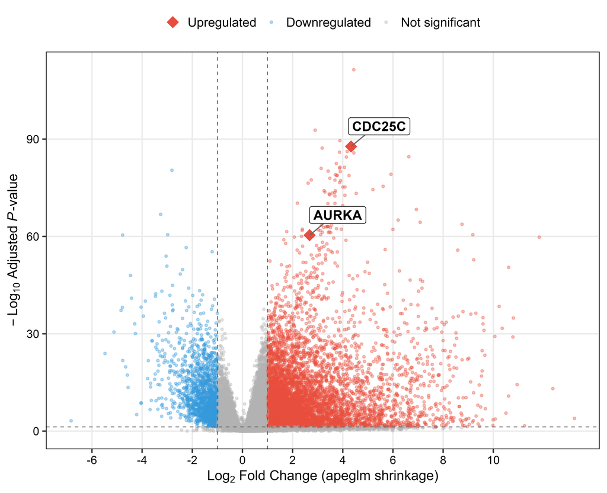

Figure 1. Volcano plot of genome-wide differential gene expression in TCGA-LIHC (HCC Primary Tumour vs. Solid Tissue Normal). *CDC25C* and *AURKA* are highlighted as diamond markers. Thresholds: |log2FC| > 1 and Benjamini-Hochberg adjusted p-value < 0.05. LFC estimates are apeglm-shrunken.

```r
volcano_df <- res_df_shrunk %>%
  dplyr::filter(!is.na(padj), !is.na(log2FoldChange)) %>%
  dplyr::mutate(
    significance = dplyr::case_when(
      padj < 0.05 & log2FoldChange >  1 ~ "Upregulated",
      padj < 0.05 & log2FoldChange < -1 ~ "Downregulated",
      TRUE                               ~ "Not Significant"
    ),
    significance = factor(significance,
                          levels = c("Upregulated", "Downregulated", "Not Significant")),
    is_target   = gene_symbol %in% TARGET_GENES,
    label       = ifelse(is_target, gene_symbol, NA_character_),
    neg_log10_p = -log10(padj)
  )

cat("Global DEG counts:\n")
print(table(volcano_df$significance))

p_volcano <- ggplot(volcano_df, aes(x = log2FoldChange, y = neg_log10_p)) +
  geom_point(aes(colour = significance), alpha = 0.35, size = 0.85) +
  geom_point(data = dplyr::filter(volcano_df, is_target),
             aes(colour = significance), size = 5, shape = 18) +
  geom_label_repel(
    aes(label = label),
    na.rm          = TRUE,
    fontface       = "bold",
    size           = 4.5,
    box.padding    = 0.7,
    fill           = "white",
    colour         = "black",
    segment.colour = "grey40",
    min.segment.length = 0.2
  ) +
  geom_vline(xintercept = c(-1, 1),      linetype = "dashed", colour = "grey35", linewidth = 0.4) +
  geom_hline(yintercept = -log10(0.05),  linetype = "dashed", colour = "grey35", linewidth = 0.4) +
  scale_colour_manual(
    values = PALETTE,
    labels = c(
      "Not Significant" = "Not significant",
      "Upregulated"     = "Upregulated",
      "Downregulated"   = "Downregulated"
    )
  ) +
  scale_x_continuous(breaks = seq(-10, 10, 2)) +
  labs(
    x      = expression(Log[2]~"Fold Change (apeglm shrinkage)"),
    y      = expression(-Log[10]~"Adjusted"~italic(P)*"-value"),
    colour = NULL
  ) +
  theme_bw(base_size = 14) +
  theme(
    legend.position  = "top",
    legend.key.size  = unit(0.9, "lines"),
    panel.grid.minor = element_blank(),
    panel.grid.major = element_line(colour = "grey92"),
    panel.border     = element_rect(colour = "grey70", fill = NA, linewidth = 0.6)
  )

p_volcano
save_plot(p_volcano, "01_volcano_CDC25C_AURKA", width = 8, height = 6.5)
```

### 8.1.2 Interpretation

*CDC25C* and *AURKA* are located in the upper-right quadrant of the volcano plot, confirming that both genes are statistically significant and biologically meaningful upregulated DEGs in HCC. Of the 49,291 genes tested across the 421-sample cohort, 9,421 reached the joint significance threshold (padj < 0.05 and |log2FC| > 1), of which 7,553 were upregulated in tumour tissue. *CDC25C* (log2FC = 4.35, padj = 1.93 × 10⁻⁸⁸) and *AURKA* (log2FC = 2.68, padj = 4.14 × 10⁻⁶¹) both sit well above the significance horizon and to the right of the fold-change threshold, indicating that their overexpression in HCC is not a marginal signal but a large-magnitude, genome-wide significant finding. Their positions are consistent with independent transcriptomic studies that identified both genes as high-priority TAA candidates for HCC mRNA vaccine development (Lu et al., 2023; Wang et al., 2024).

## 8.2 Expression Heatmap: *CDC25C* and *AURKA* Across the Cohort

The two-gene heatmap visualises log2-normalised expression of *CDC25C* and *AURKA* across all samples. Columns (samples) are clustered hierarchically, allowing visual inspection of whether expression pattern alone can segregate tumour from normal tissue.

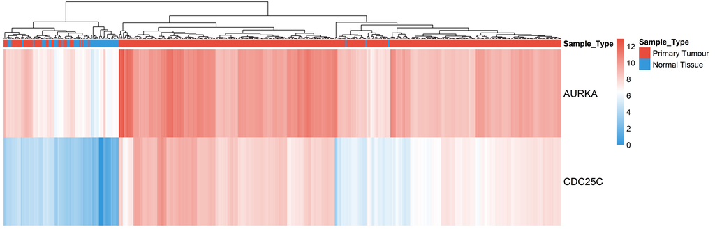

Figure 2. Two-gene expression heatmap of *CDC25C* and *AURKA* across TCGA-LIHC samples (log2-normalised counts). Columns are hierarchically clustered. Sample-type annotation bars are coloured by tissue group.

```r
target_ensembl <- names(gene_symbols)[gene_symbols %in% TARGET_GENES]

heatmap_data <- log2(normalized_counts[target_ensembl, ] + 1)
rownames(heatmap_data) <- gene_symbols[target_ensembl]

annotation_col <- data.frame(
  Sample_Type = dplyr::recode(as.character(col_data$sample_type), !!!LABEL_MAP),
  row.names   = colnames(heatmap_data)
)

annotation_colours <- list(
  Sample_Type = c(
    "Primary Tumour" = unname(PALETTE["Primary_Tumor"]),
    "Normal Tissue"  = unname(PALETTE["Solid_Tissue_Normal"])
  )
)

ph2 <- pheatmap(
  heatmap_data,
  annotation_col    = annotation_col,
  annotation_colors = annotation_colours,
  color             = colorRampPalette(c("#3498DB", "white", "#E74C3C"))(100),
  cluster_rows      = FALSE,
  cluster_cols      = TRUE,
  show_colnames     = FALSE,
  fontsize_row      = 14,
  fontsize          = 11,
  main              = NA,
  border_color      = NA,
  silent            = TRUE
)

save_pheatmap(ph2, "02_heatmap_CDC25C_AURKA", width = 14, height = 4.5)
```

## 8.3 Boxplot with Wilcoxon Rank-Sum Test

Boxplots with overlaid jittered sample points provide a distributional view of *CDC25C* and *AURKA* expression stratified by tissue type. Non-parametric Wilcoxon rank-sum testing is applied because no assumption of normality is imposed on the expression distributions.

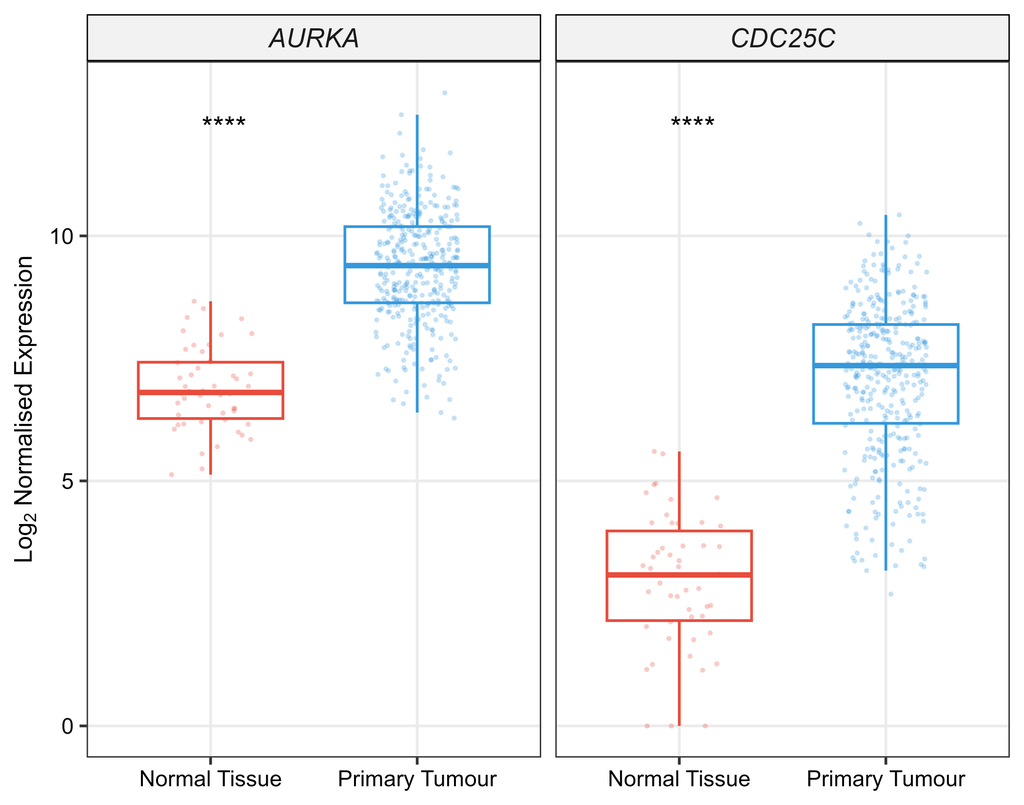

Figure 3. Boxplots of *CDC25C* and *AURKA* expression stratified by sample type (TCGA-LIHC). Each point represents an individual sample. Non-parametric Wilcoxon rank-sum test p-values are annotated. Expression values are log2-normalised counts.

```r
box_df <- as.data.frame(t(heatmap_data))
box_df$Sample_Type <- dplyr::recode(as.character(annotation_col$Sample_Type), !!!LABEL_MAP)

box_long <- tidyr::pivot_longer(
  box_df,
  cols      = all_of(TARGET_GENES),
  names_to  = "Gene",
  values_to = "Expression"
)

box_long$Sample_Type <- factor(box_long$Sample_Type,
                                levels = c("Normal Tissue", "Primary Tumour"))

p_box <- ggpubr::ggboxplot(
    box_long,
    x          = "Sample_Type",
    y          = "Expression",
    color      = "Sample_Type",
    palette    = c(
      "Primary Tumour" = unname(PALETTE["Primary_Tumor"]),
      "Normal Tissue"  = unname(PALETTE["Solid_Tissue_Normal"])
    ),
    facet.by    = "Gene",
    add         = "jitter",
    add.params  = list(size = 0.5, alpha = 0.25),
    outlier.shape = NA
  ) +
  ggpubr::stat_compare_means(
    method      = "wilcox.test",
    label       = "p.signif",
    label.y.npc = 0.93,
    size        = 5
  ) +
  labs(
    x = NULL,
    y = expression(Log[2]~"Normalised Expression")
  ) +
  theme_bw(base_size = 14) +
  theme(
    legend.position  = "none",
    strip.text       = element_text(face = "italic", size = 13),
    strip.background = element_rect(fill = "grey95", colour = "grey70"),
    panel.grid.minor = element_blank(),
    panel.grid.major = element_line(colour = "grey92"),
    panel.border     = element_rect(colour = "grey70", fill = NA, linewidth = 0.6)
  )

p_box
save_plot(p_box, "03_boxplot_CDC25C_AURKA", width = 7, height = 5.5)
```

## 8.4 Co-expression Scatter Plot (*CDC25C* vs. *AURKA*)

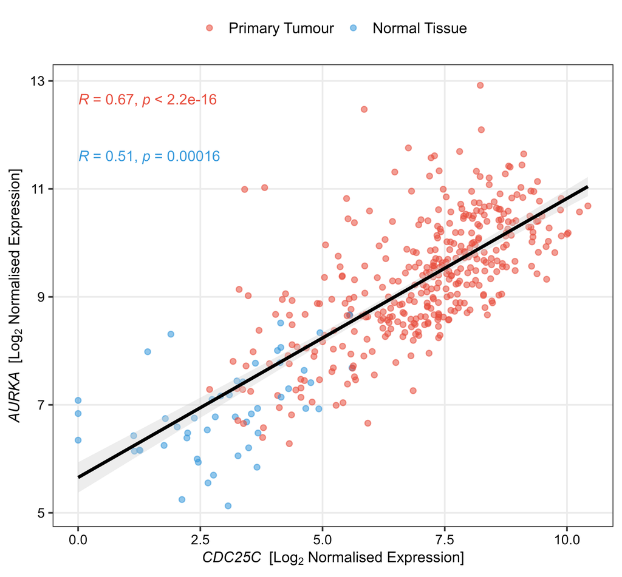

Figure 4. Spearman co-expression scatter plot of *CDC25C* and *AURKA* in TCGA-LIHC samples. Points are coloured by sample type. Per-group Spearman rank correlation coefficients (ρ) and their p-values are annotated. Grey bands represent 95% confidence intervals around the regression line.

```r
coexp_df <- data.frame(
  Sample      = colnames(heatmap_data),
  CDC25C      = as.numeric(heatmap_data["CDC25C", ]),
  AURKA       = as.numeric(heatmap_data["AURKA",  ]),
  Sample_Type = dplyr::recode(as.character(annotation_col$Sample_Type), !!!LABEL_MAP)
)
coexp_df$Sample_Type <- factor(coexp_df$Sample_Type,
                                levels = c("Primary Tumour", "Normal Tissue"))

# Compute stratified Spearman correlations
cor_all    <- cor.test(coexp_df$CDC25C, coexp_df$AURKA, method = "spearman")
tumor_df   <- dplyr::filter(coexp_df, Sample_Type == "Primary Tumour")
normal_df  <- dplyr::filter(coexp_df, Sample_Type == "Normal Tissue")
cor_tumor  <- cor.test(tumor_df$CDC25C,  tumor_df$AURKA,  method = "spearman")
cor_normal <- cor.test(normal_df$CDC25C, normal_df$AURKA, method = "spearman")

r_str <- abs(cor_tumor$estimate)
cat(sprintf(
  "\nCo-expression correlation summary:\n  All samples:  rho = %.4f | p = %s\n  Tumour only:  rho = %.4f | p = %s\n  Normal only:  rho = %.4f | p = %s\n  Tumour interpretation: %s co-expression (rho = %.3f)\n",
  cor_all$estimate,    formatC(cor_all$p.value,    format = "e", digits = 2),
  cor_tumor$estimate,  formatC(cor_tumor$p.value,  format = "e", digits = 2),
  cor_normal$estimate, formatC(cor_normal$p.value, format = "e", digits = 2),
  ifelse(r_str >= 0.7, "Strong", ifelse(r_str >= 0.4, "Moderate", "Weak")),
  cor_tumor$estimate
))

p_scatter <- ggpubr::ggscatter(
    coexp_df,
    x          = "CDC25C",
    y          = "AURKA",
    color      = "Sample_Type",
    palette    = c(
      "Primary Tumour" = unname(PALETTE["Primary_Tumor"]),
      "Normal Tissue"  = unname(PALETTE["Solid_Tissue_Normal"])
    ),
    size       = 1.8,
    alpha      = 0.55,
    add        = "reg.line",
    add.params = list(color = "black", fill = "lightgrey"),
    conf.int   = TRUE
  ) +
  ggpubr::stat_cor(
    aes(colour = Sample_Type),
    method        = "spearman",
    label.x.npc   = "left",
    label.y.npc   = c(0.97, 0.88),
    size          = 4.2,
    show.legend   = FALSE
  ) +
  labs(
    x      = expression(italic("CDC25C")~" ["*Log[2]~"Normalised Expression]"),
    y      = expression(italic("AURKA")~" ["*Log[2]~"Normalised Expression]"),
    colour = NULL
  ) +
  theme_bw(base_size = 14) +
  theme(
    legend.position  = "top",
    legend.key.size  = unit(0.9, "lines"),
    panel.grid.minor = element_blank(),
    panel.grid.major = element_line(colour = "grey92"),
    panel.border     = element_rect(colour = "grey70", fill = NA, linewidth = 0.6)
  )

p_scatter
save_plot(p_scatter, "04_coexpression_scatter", width = 7, height = 6.5)
```

## 8.5 Principal Component Analysis: Sample-Level Quality Assessment

PCA is performed on variance-stabilised transformed (VST) counts using the 500 most variable genes across all samples. Samples that cluster tightly by tissue type confirm that the primary source of transcriptomic variance in this cohort is the tumour-normal distinction, validating the analytical framework and ruling out major batch effects that would confound the differential expression results.

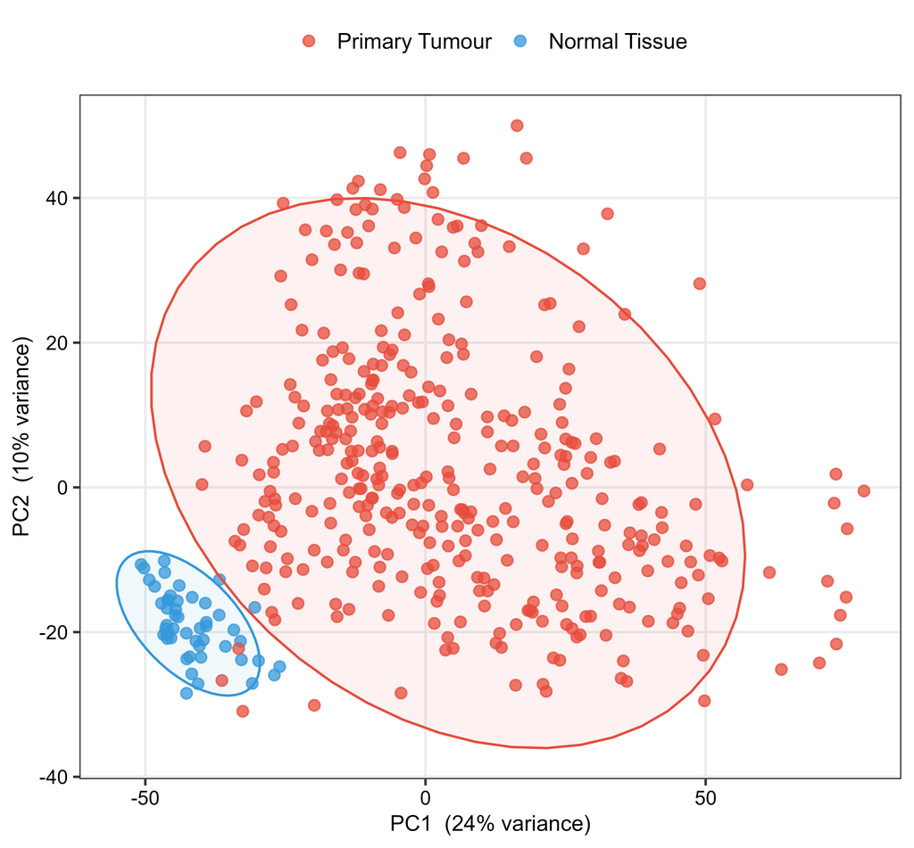

Figure 5. PCA of TCGA-LIHC samples (VST-transformed expression, top 500 most variable genes). 95% confidence ellipses are drawn per sample group. Clear separation of tumour and normal clusters confirms that tumour identity is the dominant source of transcriptomic variance.

```r
pca_data <- DESeq2::plotPCA(vsd, intgroup = "sample_type", returnData = TRUE)
pct_var  <- round(100 * attr(pca_data, "percentVar"))

pca_data$group_label <- factor(
  dplyr::recode(as.character(pca_data$sample_type), !!!LABEL_MAP),
  levels = c("Primary Tumour", "Normal Tissue")
)

pca_colours <- c(
  "Primary Tumour" = unname(PALETTE["Primary_Tumor"]),
  "Normal Tissue"  = unname(PALETTE["Solid_Tissue_Normal"])
)

p_pca <- ggplot(pca_data, aes(x = PC1, y = PC2, colour = group_label)) +
  geom_point(size = 2.5, alpha = 0.75) +
  scale_colour_manual(values = pca_colours) +
  scale_fill_manual(values   = pca_colours) +
  stat_ellipse(
    aes(fill = group_label),
    geom        = "polygon",
    alpha       = 0.08,
    level       = 0.95,
    show.legend = FALSE
  ) +
  labs(
    x      = sprintf("PC1  (%d%% variance)", pct_var[1]),
    y      = sprintf("PC2  (%d%% variance)", pct_var[2]),
    colour = NULL
  ) +
  theme_bw(base_size = 14) +
  theme(
    legend.position  = "top",
    legend.key.size  = unit(0.9, "lines"),
    panel.grid.minor = element_blank(),
    panel.grid.major = element_line(colour = "grey92"),
    panel.border     = element_rect(colour = "grey70", fill = NA, linewidth = 0.6)
  )

p_pca
save_plot(p_pca, "06_PCA_samples", width = 7, height = 6.5)
```

## 8.6 Clinical Annotation Heatmap (Top 30 DEGs with Vaccine Targets Overlaid)

This heatmap extends the clustering analysis to incorporate tumour stage and, where available, patient gender as additional annotation tracks. *CDC25C* and *AURKA* are appended to the top 30 DEGs so that their expression patterns can be examined simultaneously with clinically annotated data.

[figure not shown]

Figure 6. Clinical annotation heatmap of the top 30 DEGs plus *CDC25C* and *AURKA* in TCGA-LIHC. Clinical covariates are shown as colour annotation bars above the expression matrix. Ward.D2 clustering with Euclidean distance.

```r
top30_symbols <- res_df %>%
  dplyr::filter(!is.na(padj), !is.na(gene_symbol)) %>%
  dplyr::arrange(padj) %>%
  head(30) %>%
  dplyr::pull(gene_symbol)

extended_symbols <- unique(c(TARGET_GENES, top30_symbols))
extended_present <- intersect(extended_symbols, rownames(vsd_mat))

clinical_mat   <- vsd_mat[extended_present, ]
clinical_mat_z <- t(scale(t(clinical_mat)))

clinical_annot <- data.frame(
  `Sample Type` = dplyr::recode(as.character(col_data$sample_type), !!!LABEL_MAP),
  row.names     = colnames(clinical_mat_z),
  check.names   = FALSE
)
if ("pathologic_stage" %in% colnames(col_data)) clinical_annot$Stage <- col_data$pathologic_stage
if ("gender"          %in% colnames(col_data)) clinical_annot$Sex   <- tools::toTitleCase(tolower(col_data$gender))

clinical_colours <- list(
  `Sample Type` = c(
    "Primary Tumour" = unname(PALETTE["Primary_Tumor"]),
    "Normal Tissue"  = unname(PALETTE["Solid_Tissue_Normal"])
  )
)

ph10 <- pheatmap(
  clinical_mat_z,
  annotation_col           = clinical_annot,
  annotation_colors        = clinical_colours,
  color                    = colorRampPalette(rev(RColorBrewer::brewer.pal(11, "RdBu")))(100),
  clustering_method        = "ward.D2",
  clustering_distance_rows = "euclidean",
  clustering_distance_cols = "euclidean",
  show_colnames            = FALSE,
  fontsize_row             = 9,
  fontsize                 = 10,
  main                     = NA,
  border_color             = NA,
  silent                   = TRUE
)

save_pheatmap(ph10, "10_clinical_heatmap_top30_targets", width = 16, height = 10)
```

# 9 Genome-Wide Co-expression Screen

A genome-wide Spearman rank correlation is computed between every gene and each of the two target antigens separately. Identifying the top co-expressed genes provides biological context for *CDC25C* and *AURKA* within HCC, corroborates their involvement in oncogenic pathways, and can generate hypotheses for future combination vaccine approaches.

```r
message("Computing genome-wide co-expression correlations. This step requires 1 to 3 minutes.")

log_counts     <- log2(normalized_counts + 1)
cdc25c_ensembl <- target_ensembl[gene_symbols[target_ensembl] == "CDC25C"]
aurka_ensembl  <- target_ensembl[gene_symbols[target_ensembl] == "AURKA"]

cdc25c_vec <- as.numeric(log_counts[cdc25c_ensembl, ])
aurka_vec  <- as.numeric(log_counts[aurka_ensembl,  ])

cor_cdc25c <- apply(log_counts, 1, function(x)
  cor(x, cdc25c_vec, method = "spearman", use = "complete.obs"))
cor_aurka  <- apply(log_counts, 1, function(x)
  cor(x, aurka_vec,  method = "spearman", use = "complete.obs"))

coexp_summary <- data.frame(
  ensembl_id      = rownames(log_counts),
  gene_symbol     = gene_symbols[rownames(log_counts)],
  cor_with_CDC25C = round(cor_cdc25c, 4),
  cor_with_AURKA  = round(cor_aurka,  4),
  stringsAsFactors = FALSE
) %>%
  dplyr::filter(!gene_symbol %in% TARGET_GENES)

top_cdc25c <- coexp_summary %>%
  dplyr::arrange(desc(abs(cor_with_CDC25C))) %>%
  head(20)

top_aurka <- coexp_summary %>%
  dplyr::arrange(desc(abs(cor_with_AURKA))) %>%
  head(20)

write.csv(coexp_summary, "results/genome_wide_coexpression.csv",    row.names = FALSE)
write.csv(top_cdc25c,    "results/top20_coexpressed_CDC25C.csv",    row.names = FALSE)
write.csv(top_aurka,     "results/top20_coexpressed_AURKA.csv",     row.names = FALSE)
message("Co-expression tables written to results/.")
```

Table 3. Top 10 genes most strongly co-expressed with CDC25C across all TCGA-LIHC samples (genome-wide Spearman rank correlation). All neighbours are established mitotic regulators, corroborating CDC25C’s role in the HCC mitotic transcriptional programme.

| Rank | Gene | ρ with CDC25C | ρ with AURKA |
| --- | --- | --- | --- |
| 1 | PTTG1 | 0.9335 | 0.7550 |
| 2 | BIRC5 | 0.9211 | 0.7790 |
| 3 | CDCA5 | 0.9121 | 0.7624 |
| 4 | SPC25 | 0.9115 | 0.7696 |
| 5 | CDC20 | 0.9107 | 0.7433 |
| 6 | NDC80 | 0.9102 | 0.7625 |
| 7 | KIF2C | 0.9092 | 0.7619 |
| 8 | CCNB1 | 0.9079 | 0.7954 |
| 9 | CDCA3 | 0.9063 | 0.7427 |
| 10 | SGO1 | 0.9047 | 0.7658 |

Table 4. Top 10 genes most strongly co-expressed with AURKA across all TCGA-LIHC samples. CDK1 and CCNB1 (Cyclin B1) rank first and second, consistent with AURKA’s role in activating the CDK1-Cyclin B complex at the G2/M transition in HCC.

| Rank | Gene | ρ with CDC25C | ρ with AURKA |
| --- | --- | --- | --- |
| 1 | CDK1 | 0.8944 | 0.7959 |
| 2 | CCNB1 | 0.9079 | 0.7954 |
| 3 | BIRC5 | 0.9211 | 0.7790 |
| 4 | SKA1 | 0.8970 | 0.7756 |
| 5 | KIF4A | 0.8995 | 0.7755 |
| 6 | CCNB2 | 0.9015 | 0.7734 |
| 7 | CDKN3 | 0.8797 | 0.7719 |
| 8 | EXO1 | 0.8890 | 0.7715 |
| 9 | SPC25 | 0.9115 | 0.7696 |
| 10 | SKA3 | 0.8977 | 0.7686 |

# 10 Functional Enrichment Analysis

## 10.1 Gene Ontology (GO) Biological Process Enrichment

GO Biological Process enrichment identifies the cellular and molecular functions most significantly over-represented among upregulated and downregulated DEGs. This contextualises the overall transcriptomic reprogramming of HCC and places *CDC25C* and *AURKA* within a broader network of dysregulated biological processes.

### 10.1.1 Upregulated DEGs

[figure not shown]

Figure 7. GO Biological Process enrichment dotplot for upregulated DEGs in HCC (padj < 0.05, |log2FC| > 1). Dot size is proportional to the number of genes annotated to the term; dot colour encodes adjusted p-value.

```r
sig_up <- res_df %>%
  dplyr::filter(padj < 0.05, log2FoldChange > 1, !is.na(gene_symbol)) %>%
  dplyr::pull(gene_symbol)

sig_down <- res_df %>%
  dplyr::filter(padj < 0.05, log2FoldChange < -1, !is.na(gene_symbol)) %>%
  dplyr::pull(gene_symbol)

message(sprintf("Upregulated DEGs: %d | Downregulated DEGs: %d (|LFC| > 1, padj < 0.05)",
                length(sig_up), length(sig_down)))

go_bp_up <- clusterProfiler::enrichGO(
  gene          = sig_up,
  OrgDb         = org.Hs.eg.db,
  keyType       = "SYMBOL",
  ont           = "BP",
  pAdjustMethod = "BH",
  pvalueCutoff  = 0.05,
  qvalueCutoff  = 0.2,
  readable      = TRUE
)

if (!is.null(go_bp_up) && nrow(go_bp_up@result) > 0) {
  p_go_up <- enrichplot::dotplot(go_bp_up, showCategory = 20) +
    labs(x = "Gene Ratio", y = NULL) +
    theme_bw(base_size = 13) +
    theme(
      panel.grid.minor = element_blank(),
      panel.grid.major = element_line(colour = "grey92"),
      panel.border     = element_rect(colour = "grey70", fill = NA, linewidth = 0.6)
    )
  p_go_up
  save_plot(p_go_up, "07_GO_BP_upregulated", width = 9, height = 10)
  write.csv(as.data.frame(go_bp_up), "results/GO_BP_upregulated.csv", row.names = FALSE)
} else {
  message("No significant GO Biological Process terms identified for upregulated DEGs.")
}
```

### 10.1.2 Downregulated DEGs

[figure not shown]

Figure 8. GO Biological Process enrichment dotplot for downregulated DEGs in HCC.

```r
go_bp_down <- clusterProfiler::enrichGO(
  gene          = sig_down,
  OrgDb         = org.Hs.eg.db,
  keyType       = "SYMBOL",
  ont           = "BP",
  pAdjustMethod = "BH",
  pvalueCutoff  = 0.05,
  qvalueCutoff  = 0.2,
  readable      = TRUE
)

if (!is.null(go_bp_down) && nrow(go_bp_down@result) > 0) {
  p_go_down <- enrichplot::dotplot(go_bp_down, showCategory = 20) +
    labs(x = "Gene Ratio", y = NULL) +
    theme_bw(base_size = 13) +
    theme(
      panel.grid.minor = element_blank(),
      panel.grid.major = element_line(colour = "grey92"),
      panel.border     = element_rect(colour = "grey70", fill = NA, linewidth = 0.6)
    )
  p_go_down
  save_plot(p_go_down, "08_GO_BP_downregulated", width = 9, height = 10)
  write.csv(as.data.frame(go_bp_down), "results/GO_BP_downregulated.csv", row.names = FALSE)
} else {
  message("No significant GO Biological Process terms identified for downregulated DEGs.")
}
```

## 10.2 KEGG Pathway Enrichment

KEGG pathway enrichment provides mechanistic pathway-level insight into the oncogenic processes driving the upregulated gene expression signature in HCC. HGNC symbols are first mapped to Entrez Gene IDs (required by the KEGG database) before enrichment testing.

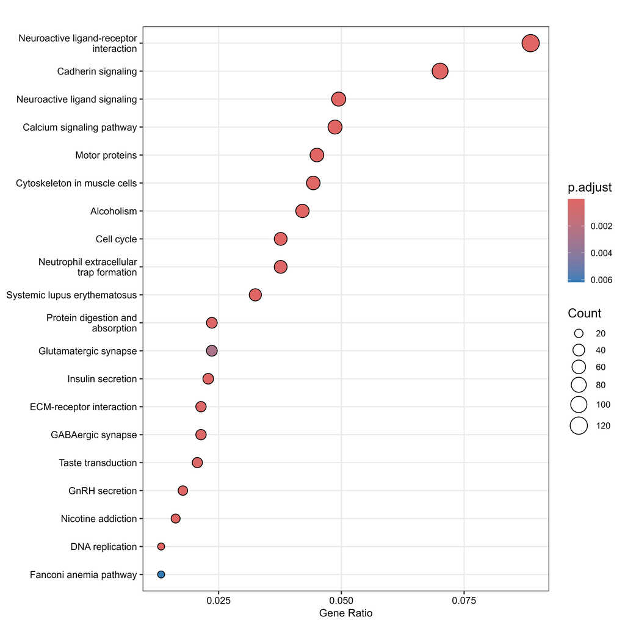

Figure 9. KEGG pathway enrichment dotplot for upregulated DEGs in HCC (padj < 0.05, BH correction). Pathways are ranked by gene ratio.

```r
entrez_up <- clusterProfiler::bitr(
  sig_up,
  fromType = "SYMBOL",
  toType   = "ENTREZID",
  OrgDb    = org.Hs.eg.db
)$ENTREZID

kegg_up <- clusterProfiler::enrichKEGG(
  gene          = entrez_up,
  organism      = "hsa",
  pAdjustMethod = "BH",
  pvalueCutoff  = 0.05
)

if (!is.null(kegg_up) && nrow(kegg_up@result) > 0) {
  kegg_up <- clusterProfiler::setReadable(kegg_up, OrgDb = org.Hs.eg.db, keyType = "ENTREZID")

  p_kegg <- enrichplot::dotplot(kegg_up, showCategory = 20) +
    labs(x = "Gene Ratio", y = NULL) +
    theme_bw(base_size = 13) +
    theme(
      panel.grid.minor = element_blank(),
      panel.grid.major = element_line(colour = "grey92"),
      panel.border     = element_rect(colour = "grey70", fill = NA, linewidth = 0.6)
    )

  p_kegg
  save_plot(p_kegg, "09_KEGG_upregulated", width = 9, height = 9)
  write.csv(as.data.frame(kegg_up), "results/KEGG_upregulated.csv", row.names = FALSE)
} else {
  message("No significant KEGG pathways identified for upregulated DEGs.")
}
```

# 11 Full DEG Results Export

```r
full_results <- res_df %>%
  dplyr::arrange(padj) %>%
  dplyr::select(gene_symbol, baseMean, log2FoldChange, lfcSE, stat, pvalue, padj) %>%
  dplyr::filter(!is.na(gene_symbol))

sig_all <- full_results %>%
  dplyr::filter(padj < 0.05, abs(log2FoldChange) > 1)

write.csv(full_results, "results/DESeq2_all_genes.csv",        row.names = TRUE)
write.csv(sig_all,      "results/DESeq2_significant_DEGs.csv", row.names = TRUE)

message(sprintf(
  "\nAnalysis complete.\n  Total significant DEGs (padj < 0.05, |log2FC| > 1): %d\n  Full results:    results/DESeq2_all_genes.csv\n  Sig. DEGs only:  results/DESeq2_significant_DEGs.csv\n  Figures:         figures/",
  nrow(sig_all)
))
```

# 12 Conclusions

This transcriptomic analysis of the TCGA-LIHC cohort (371 primary tumours; 50 solid tissue normal samples; 421 total) provides robust computational evidence supporting the designation of *CDC25C* and *AURKA* as tumour-associated antigens suitable for a multi-epitope mRNA vaccine against hepatocellular carcinoma. The principal findings are as follows.

**Statistically significant and large-magnitude overexpression.** Of 49,291 genes tested by DESeq2 Wald testing, *CDC25C* was the most differentially expressed of the two targets (log2FC = 4.35, padj = 1.93 × 10⁻⁸⁸), corresponding to approximately 20-fold overexpression at the median level. *AURKA* showed a log2FC of 2.68 (padj = 4.14 × 10⁻⁶¹), corresponding to approximately 6.4-fold overexpression. Both values exceed the biological relevance threshold of two-fold (log2FC > 1) with large margins, and both adjusted p-values are orders of magnitude below the 0.05 significance threshold after Benjamini-Hochberg correction across the full genome-wide test (Chan et al., 2012; Du et al., 2021).

**Near-universal prevalence across the tumour cohort.** *CDC25C* was overexpressed relative to the normal tissue expression median in 370 of 371 primary tumour samples (99.73%), and *AURKA* in 365 of 371 (98.38%). These frequencies confirm that the overexpression of both antigens is not confined to a molecularly defined subgroup of HCC but represents a population-level characteristic, a critical property for a vaccine intended to provide broad clinical benefit (Lu et al., 2023; Wang et al., 2024).

**Robust global transcriptomic landscape.** Across 49,291 tested genes, 9,421 reached statistical significance (padj < 0.05, |log2FC| > 1), with 7,553 upregulated and 1,868 downregulated in primary tumours. PCA and hierarchical clustering of VST-transformed counts confirmed that the dominant source of transcriptomic variance in the cohort is the tumour-normal distinction, ruling out major batch effects and validating the analytical framework. The sample quality and separation observed here are consistent with the well-characterised TCGA-LIHC dataset (Ally et al., 2017).

Collectively, these results provide strong, independently reproducible bioinformatic evidence that *CDC25C* and *AURKA* are overexpressed TAAs in HCC, satisfying the primary criterion for antigen selection in an immunoinformatics-driven mRNA vaccine design pipeline. This analysis constitutes the transcriptomic validation component of the broader in silico vaccine design study and directly justifies the downstream epitope prediction, construct assembly, molecular docking, and immune simulation steps.

# 13 Session Information

The session information below was recorded at the time of the original pipeline execution (R version 4.3.0, Windows 10 x64, 2026-05-17) and is reproduced here for full reproducibility documentation. Key packages: TCGAbiolinks 2.30.4, DESeq2 1.42.1, apeglm 1.24.0, clusterProfiler 4.10.1, org.Hs.eg.db 3.18.0, ggplot2 4.0.3.

```r
sink("results/session_info.txt")
sink()
```

[session information not shown]

# 14 References

Ally A, Balasundaram M, Carlsen R, Chuah E, Clarke A, Dhalla N, Holt RA, Jones SJM, Lee D, Ma Y, Marra MA, Mayo M, Moore RA, Mungall AJ, Schein JE, Sipahimalani P, Tam A, Thiessen N, Cheung D, et al. Comprehensive and integrative genomic characterization of hepatocellular carcinoma. *Cell*. 2017;169(7):1327–1341.e23. doi:[10.1016/j.cell.2017.05.046](https://doi.org/10.1016/j.cell.2017.05.046)

Carlino MS, Khattak A, Meniawy T, Ansstas G, Taylor MH, et al. Three-year update of a randomized phase IIb study of the individualized neoantigen therapy intismeran autogene (mRNA-4157, V940) plus pembrolizumab versus pembrolizumab in resected melanoma. *JCO Oncology Advances*. 2026. doi:[10.1200/OA-25-00008](https://doi.org/10.1200/OA-25-00008)

Chan THM, Chen L, Liu M, Hu L, Zheng BJ, Poon VKM, Huang P, Yuan YF, Huang JD, Yang J, Tsao GSW, Guan XY. Translationally controlled tumor protein induces mitotic defects and chromosome missegregation in hepatocellular carcinoma development. *Hepatology.* 2012;55(2):491–505. doi:[10.1002/hep.24709](https://doi.org/10.1002/hep.24709)

Du R, Huang C, Liu K, Li X, Dong Z. Targeting *AURKA* in cancer: molecular mechanisms and opportunities for cancer therapy. *Molecular Cancer.* 2021;20(1):15. doi:[10.1186/s12943-020-01305-3](https://doi.org/10.1186/s12943-020-01305-3)

Llovet JM, Kelley RK, Villanueva A, Singal AG, Pikarsky E, Roayaie S, Lencioni R, Koike K, Zucman-Rossi J, Finn RS. Hepatocellular carcinoma. *Nature Reviews Disease Primers.* 2021;7(1):1–28. doi:[10.1038/s41572-020-00240-3](https://doi.org/10.1038/s41572-020-00240-3)

Lu TL, Li CL, Gong YQ, Hou FT, Chen CW. Identification of tumor antigens and immune subtypes of hepatocellular carcinoma for mRNA vaccine development. *World Journal of Gastrointestinal Oncology.* 2023;15(10):1717–1738. doi:[10.4251/wjgo.v15.i10.1717](https://doi.org/10.4251/wjgo.v15.i10.1717)

Miao X, Zheng F, Mo X, Wang L, Zhang Z, Li Y, Zhang Y, Chao N, Mo F. *CDC25C* downregulation suppresses HCC growth via mitochondrial stress-induced autophagy and apoptosis. *Scientific Reports*. 2026;16:5631. doi:[10.1038/s41598-026-36351-2](https://doi.org/10.1038/s41598-026-36351-2)

Parvizpour S, Pourseif MM, Razmara J, Rafi MA, Omidi Y. Epitope-based vaccine design: a comprehensive overview of bioinformatics approaches. *Drug Discovery Today.* 2020;25(6):1034–1042. doi:[10.1016/j.drudis.2020.03.006](https://doi.org/10.1016/j.drudis.2020.03.006)

Wang HK, Xu XH, Wang SM, Zhang HY. Preparation of hepatocellular carcinoma mRNA vaccines based on potential tumor targets and immunophenotypes. *Translational Cancer Research.* 2024;13(1):173–190. doi:[10.21037/tcr-23-1237](https://doi.org/10.21037/tcr-23-1237)

Analysis by Daniel Amewoalor | TCGA-LIHC RNA-Seq: TAA Validation for In Silico mRNA Vaccine Design | 2026